# Pandas-Bootcamp-Part6

#### right join is the opposite of left join

```python
#We now tell pandas to preserve all the columns on the Right Dataframe
#join on 'School Name'
#Discard everything else from the left df
#That is the reason we get the long df containing a lot of NANs
```

```python
pd.merge(ivy , regions, how = 'right')
```

|  | School Name | School Type | Starting Median Salary | Mid-Career Median Salary | Region |
| --- | --- | --- | --- | --- | --- |
| 0 | Dartmouth College | Ivy League | $58,000.00 | $134,000.00 | Northeastern |
| 1 | Princeton University | Ivy League | $66,500.00 | $131,000.00 | Northeastern |
| 2 | Yale University | Ivy League | $59,100.00 | $126,000.00 | Northeastern |
| 3 | Harvard University | Ivy League | $63,400.00 | $124,000.00 | Northeastern |
| 4 | University of Pennsylvania | Ivy League | $60,900.00 | $120,000.00 | Northeastern |
| ... | ... | ... | ... | ... | ... |
| 264 | Austin Peay State University | NaN | NaN | NaN | Southern |
| 265 | Pittsburg State University | NaN | NaN | NaN | Midwestern |
| 266 | Southern Utah University | NaN | NaN | NaN | Western |
| 267 | Montana State University - Billings | NaN | NaN | NaN | Western |
| 268 | Black Hills State University | NaN | NaN | NaN | Midwestern |

269 rows × 5 columns

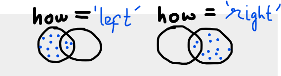

### One - to - One and One - to - Many Joins

When working with data in general .Specially when combining multiple Datasets and Tables.Sooner or later we are going to come across terminology that describes the type of association between different entities in our data.

### One to One

A One-to-One join happens when each record in a DataFrame with one Record in another dataset.

- If we look at 'ivy' dataset , we see a list of 8 unique Universities (refer to column : 'School Name')

```python
ivy
```

|  | School Name | School Type | Starting Median Salary | Mid-Career Median Salary |
| --- | --- | --- | --- | --- |
| 0 | Dartmouth College | Ivy League | $58,000.00 | $134,000.00 |
| 1 | Princeton University | Ivy League | $66,500.00 | $131,000.00 |
| 2 | Yale University | Ivy League | $59,100.00 | $126,000.00 |
| 3 | Harvard University | Ivy League | $63,400.00 | $124,000.00 |
| 4 | University of Pennsylvania | Ivy League | $60,900.00 | $120,000.00 |
| 5 | Cornell University | Ivy League | $60,300.00 | $110,000.00 |
| 6 | Brown University | Ivy League | $56,200.00 | $109,000.00 |
| 7 | Columbia University | Ivy League | $59,400.00 | $107,000.00 |

```python
regions.head()
```

|  | School Name | Region |
| --- | --- | --- |
| 0 | Massachusetts Institute of Technology (MIT) | Northeastern |
| 1 | California Institute of Technology (CIT) | California |
| 2 | Harvey Mudd College | California |
| 3 | Polytechnic University of New York, Brooklyn | Northeastern |
| 4 | Cooper Union | Northeastern |

```python
#Lets try to merge these two again
#under the hood the default parameters are 'how = inner' , on ='School Name'
#Because School Name is the only column that shares the same name across the datasets
pd.merge(ivy , regions)
```

|  | School Name | School Type | Starting Median Salary | Mid-Career Median Salary | Region |
| --- | --- | --- | --- | --- | --- |
| 0 | Dartmouth College | Ivy League | $58,000.00 | $134,000.00 | Northeastern |
| 1 | Princeton University | Ivy League | $66,500.00 | $131,000.00 | Northeastern |
| 2 | Yale University | Ivy League | $59,100.00 | $126,000.00 | Northeastern |
| 3 | Harvard University | Ivy League | $63,400.00 | $124,000.00 | Northeastern |
| 4 | University of Pennsylvania | Ivy League | $60,900.00 | $120,000.00 | Northeastern |
| 5 | Cornell University | Ivy League | $60,300.00 | $110,000.00 | Northeastern |
| 6 | Brown University | Ivy League | $56,200.00 | $109,000.00 | Northeastern |
| 7 | Columbia University | Ivy League | $59,400.00 | $107,000.00 | Northeastern |

### But , now the question is "Is this a One - to - One" JOIN ?

How can we determine whether each 'Ivy League' School ('School Type') is associated with one and only one record in the "regions" dataframe

The answer comes down to whether the two datasets bith have unique values in the resulting "Key" column That is "School Name" here.

```python
#Checking the if each "school" in regions is there in 'ivy'
```

```python
regions[regions['School Name'].isin (ivy['School Name'])]
```

|  | School Name | Region |
| --- | --- | --- |
| 86 | Dartmouth College | Northeastern |
| 87 | Princeton University | Northeastern |
| 88 | Yale University | Northeastern |
| 89 | Harvard University | Northeastern |
| 90 | University of Pennsylvania | Northeastern |
| 91 | Cornell University | Northeastern |
| 92 | Brown University | Northeastern |
| 93 | Columbia University | Northeastern |

```python
len(regions[regions['School Name'].isin (ivy['School Name'])])
```

```
8
```

- We get exactly the 8 ivy league schools
- So we confirmed that both datasets have unique values on the key column for the keys that they have in common .
- Therefore the type of join between 'ivy' and 'regions' is a One-To-One join

### One - To - Many

```python
state
```

|  | School Name | School Type | Starting Median Salary | Mid-Career Median Salary |
| --- | --- | --- | --- | --- |
| 0 | University of California, Berkeley | State | $59,900.00 | $112,000.00 |
| 1 | University of Virginia (UVA) | State | $52,700.00 | $103,000.00 |
| 2 | Cal Poly San Luis Obispo | State | $57,200.00 | $101,000.00 |
| 3 | University of California at Los Angeles (UCLA) | State | $52,600.00 | $101,000.00 |
| 4 | University of California, San Diego (UCSD) | State | $51,100.00 | $101,000.00 |
| ... | ... | ... | ... | ... |
| 170 | Austin Peay State University | State | $37,700.00 | $59,200.00 |
| 171 | Pittsburg State University | State | $40,400.00 | $58,200.00 |
| 172 | Southern Utah University | State | $41,900.00 | $56,500.00 |
| 173 | Montana State University - Billings | State | $37,900.00 | $50,600.00 |
| 174 | Black Hills State University | State | $35,300.00 | $43,900.00 |

175 rows × 4 columns

There are 175 schools in state df

```python
state['School Name'].duplicated().sum()
```

```
0
```

```python
#Another way to check if the column has unique values
state['School Name'].is_unique
```

```
True
```

- When we merge this df with another , what kind of join is it going to be ?
- Well, it depends whether the key column has all unique or duplicates

```python
regions['School Name'].duplicated().sum()
```

```
20
```

```python
#checking if the schools in regions dataframe are there in state dataframe
regions[regions['School Name'].isin(state['School Name'])]
```

|  | School Name | Region |
| --- | --- | --- |
| 19 | University of Illinois at Urbana-Champaign (UIUC) | Midwestern |
| 20 | University of Maryland, College Park | Southern |
| 21 | University of California, Santa Barbara (UCSB) | California |
| 22 | University of Texas (UT) - Austin | Southern |
| 23 | State University of New York (SUNY) at Albany | Northeastern |
| ... | ... | ... |
| 264 | Austin Peay State University | Southern |
| 265 | Pittsburg State University | Midwestern |
| 266 | Southern Utah University | Western |
| 267 | Montana State University - Billings | Western |
| 268 | Black Hills State University | Midwestern |

194 rows × 2 columns

- We are not able to make out by looking above because it is very long
- But we can very well notice that there are more than 175 names here
- So, some of them must be showing up more than once

```python
len(regions[regions['School Name'].isin(state['School Name'])])
```

```
194
```

```python
region_statedupes = regions[regions['School Name'].isin(state['School Name'])]
```

```python
region_statedupes[region_statedupes['School Name'].duplicated()]
```

|  | School Name | Region |
| --- | --- | --- |
| 102 | University of Illinois at Urbana-Champaign (UIUC) | Midwestern |
| 107 | University of Maryland, College Park | Southern |
| 108 | University of California, Santa Barbara (UCSB) | California |
| 109 | University of Texas (UT) - Austin | Southern |
| 112 | State University of New York (SUNY) at Albany | Northeastern |
| 118 | University of Florida (UF) | Southern |
| 120 | Louisiana State University (LSU) | Southern |
| 127 | University of Georgia (UGA) | Southern |
| 128 | Pennsylvania State University (PSU) | Northeastern |
| 142 | Arizona State University (ASU) | Western |
| 144 | Indiana University (IU), Bloomington | Midwestern |
| 145 | University of Iowa (UI) | Midwestern |
| 162 | University of Alabama, Tuscaloosa | Southern |
| 173 | University of Mississippi | Southern |
| 184 | University of New Hampshire (UNH) | Northeastern |
| 186 | West Virginia University (WVU) | Southern |
| 202 | University of Tennessee | Southern |
| 211 | Ohio University | Midwestern |
| 214 | Florida State University (FSU) | Southern |

```python
len(region_statedupes[region_statedupes['School Name'].duplicated()])
```

```
19
```

```python
194 - 175
```

```
19
```

- There are 19 Duplicate "School Names" in 'regions' dataset

```python
#We can also look at the value counts to understand the unique values appear more than once or not
region_statedupes['School Name'].value_counts()
```

```
University of Alabama, Tuscaloosa                    2
University of New Hampshire (UNH)                    2
University of Georgia (UGA)                          2
University of Illinois at Urbana-Champaign (UIUC)    2
Florida State University (FSU)                       2
                                                    ..
George Mason University                              1
Binghamton University                                1
University of Missouri - Kansas City (UMKC)          1
Clemson University                                   1
University of Massachusetts (UMass) - Dartmouth      1
Name: School Name, Length: 175, dtype: int64
```

- We have confirmed that the regions df does not have unique School names in the 'School Name' column

If we go ahead and do the merge on these two dfs , then we will be looking at One-To-Many association

```python
regions.head(1)
```

|  | School Name | Region |
| --- | --- | --- |
| 0 | Massachusetts Institute of Technology (MIT) | Northeastern |

```python
state.head(1)
```

|  | School Name | School Type | Starting Median Salary | Mid-Career Median Salary |
| --- | --- | --- | --- | --- |
| 0 | University of California, Berkeley | State | $59,900.00 | $112,000.00 |

```python
state.shape
```

```
(175, 4)
```

```python
pd.merge(state , regions , how ='inner' ,on='School Name')
```

|  | School Name | School Type | Starting Median Salary | Mid-Career Median Salary | Region |
| --- | --- | --- | --- | --- | --- |
| 0 | University of California, Berkeley | State | $59,900.00 | $112,000.00 | California |
| 1 | University of Virginia (UVA) | State | $52,700.00 | $103,000.00 | Southern |
| 2 | Cal Poly San Luis Obispo | State | $57,200.00 | $101,000.00 | California |
| 3 | University of California at Los Angeles (UCLA) | State | $52,600.00 | $101,000.00 | California |
| 4 | University of California, San Diego (UCSD) | State | $51,100.00 | $101,000.00 | California |
| ... | ... | ... | ... | ... | ... |
| 189 | Austin Peay State University | State | $37,700.00 | $59,200.00 | Southern |
| 190 | Pittsburg State University | State | $40,400.00 | $58,200.00 | Midwestern |
| 191 | Southern Utah University | State | $41,900.00 | $56,500.00 | Western |
| 192 | Montana State University - Billings | State | $37,900.00 | $50,600.00 | Western |
| 193 | Black Hills State University | State | $35,300.00 | $43,900.00 | Midwestern |

194 rows × 5 columns

```python
pd.merge(state , regions , how ='inner' ,on='School Name').tail(50)
```

|  | School Name | School Type | Starting Median Salary | Mid-Career Median Salary | Region |
| --- | --- | --- | --- | --- | --- |
| 144 | University of Texas at El Paso (UTEP) | State | $43,400.00 | $72,100.00 | Southern |
| 145 | California State University, Dominguez Hills (... | State | $42,700.00 | $72,100.00 | California |
| 146 | University Of Maine | State | $41,200.00 | $72,100.00 | Northeastern |
| 147 | Eastern Michigan University | State | $40,300.00 | $72,100.00 | Midwestern |
| 148 | Bowling Green State University | State | $39,800.00 | $72,100.00 | Midwestern |
| 149 | University of Montana | State | $37,300.00 | $71,900.00 | Western |
| 150 | University of Central Florida (UCF) | State | $42,600.00 | $71,700.00 | Southern |
| 151 | University of South Carolina | State | $40,000.00 | $71,700.00 | Southern |
| 152 | University of Nevada, Las Vegas (UNLV) | State | $45,200.00 | $71,600.00 | Western |
| 153 | St. Cloud State University | State | $41,800.00 | $71,400.00 | Midwestern |
| 154 | University of Wisconsin (UW) - Parkside | State | $40,700.00 | $71,400.00 | Midwestern |
| 155 | California State University (CSU), Stanislaus | State | $38,000.00 | $71,400.00 | California |
| 156 | Humboldt State University | State | $42,600.00 | $71,300.00 | California |
| 157 | Florida Atlantic University (FAU) | State | $42,600.00 | $71,100.00 | Southern |
| 158 | University of South Florida (USF) | State | $41,100.00 | $71,100.00 | Southern |
| 159 | Portland State University (PSU) | State | $42,600.00 | $70,900.00 | Western |
| 160 | Eastern Washington University | State | $38,600.00 | $70,900.00 | Western |
| 161 | University of Texas at San Antonio (UTSA) | State | $42,500.00 | $70,700.00 | Southern |
| 162 | University of Akron | State | $41,100.00 | $70,300.00 | Midwestern |
| 163 | State University of New York (SUNY) at Potsdam | State | $38,000.00 | $70,300.00 | Northeastern |
| 164 | University of Alabama at Birmingham (UAB) | State | $39,200.00 | $70,100.00 | Southern |
| 165 | University of Memphis (U of M) | State | $41,400.00 | $69,700.00 | Southern |
| 166 | Boise State University (BSU) | State | $40,800.00 | $69,500.00 | Western |
| 167 | Missouri State University (MSU) | State | $36,100.00 | $69,500.00 | Midwestern |
| 168 | University of Wisconsin (UW) - La Crosse | State | $42,200.00 | $69,300.00 | Midwestern |
| 169 | Appalachian State University | State | $40,400.00 | $69,100.00 | Southern |
| 170 | Virginia Commonwealth University (VCU) | State | $42,000.00 | $68,400.00 | Southern |
| 171 | University of Wisconsin (UW) - Stout | State | $43,600.00 | $68,300.00 | Midwestern |
| 172 | East Carolina University (ECU) | State | $40,200.00 | $67,500.00 | Southern |
| 173 | Utah Valley State College | State | $42,400.00 | $67,100.00 | Western |
| 174 | University of Missouri - St. Louis (UMSL) | State | $41,400.00 | $67,100.00 | Midwestern |
| 175 | Western Carolina University | State | $36,900.00 | $66,600.00 | Southern |
| 176 | University of Wisconsin (UW) - Oshkosh | State | $39,300.00 | $66,400.00 | Midwestern |
| 177 | State University of New York (SUNY) at Fredonia | State | $37,800.00 | $66,200.00 | Northeastern |
| 178 | University of Missouri - Kansas City (UMKC) | State | $38,900.00 | $65,800.00 | Midwestern |
| 179 | University of Wisconsin (UW) - Eau Claire | State | $41,400.00 | $64,800.00 | Midwestern |
| 180 | Ball State University (BSU) | State | $39,100.00 | $64,500.00 | Midwestern |
| 181 | University of North Carolina at Wilmington (UNCW) | State | $37,500.00 | $64,400.00 | Southern |
| 182 | University of Wisconsin (UW) - Stevens Point | State | $39,800.00 | $64,000.00 | Midwestern |
| 183 | University of Southern Maine | State | $39,400.00 | $63,600.00 | Northeastern |
| 184 | Arkansas State University (ASU) | State | $38,700.00 | $63,300.00 | Southern |
| 185 | Kent State University | State | $38,700.00 | $62,600.00 | Midwestern |
| 186 | Tarleton State University (TSU) | State | $40,800.00 | $62,400.00 | Southern |
| 187 | University of Wisconsin (UW) - Green Bay | State | $35,800.00 | $60,600.00 | Midwestern |
| 188 | Morehead State University | State | $34,800.00 | $60,600.00 | Southern |
| 189 | Austin Peay State University | State | $37,700.00 | $59,200.00 | Southern |
| 190 | Pittsburg State University | State | $40,400.00 | $58,200.00 | Midwestern |
| 191 | Southern Utah University | State | $41,900.00 | $56,500.00 | Western |
| 192 | Montana State University - Billings | State | $37,900.00 | $50,600.00 | Western |
| 193 | Black Hills State University | State | $35,300.00 | $43,900.00 | Midwestern |

```python
dupes = pd.merge(state , regions , how ='inner' ,on='School Name')
```

```python
dupes[dupes['School Name'].duplicated()]
```

|  | School Name | School Type | Starting Median Salary | Mid-Career Median Salary | Region |
| --- | --- | --- | --- | --- | --- |
| 9 | University of Illinois at Urbana-Champaign (UIUC) | State | $52,900.00 | $96,100.00 | Midwestern |
| 15 | University of Maryland, College Park | State | $52,000.00 | $95,000.00 | Southern |
| 17 | University of California, Santa Barbara (UCSB) | State | $50,500.00 | $95,000.00 | California |
| 19 | University of Texas (UT) - Austin | State | $49,700.00 | $93,900.00 | Southern |
| 23 | State University of New York (SUNY) at Albany | State | $44,500.00 | $92,200.00 | Northeastern |
| 30 | University of Florida (UF) | State | $47,100.00 | $87,900.00 | Southern |
| 33 | Louisiana State University (LSU) | State | $46,900.00 | $87,800.00 | Southern |
| 41 | University of Georgia (UGA) | State | $44,100.00 | $86,000.00 | Southern |
| 43 | Pennsylvania State University (PSU) | State | $49,900.00 | $85,700.00 | Northeastern |
| 58 | Arizona State University (ASU) | State | $47,400.00 | $84,100.00 | Western |
| 61 | Indiana University (IU), Bloomington | State | $46,300.00 | $84,000.00 | Midwestern |
| 63 | University of Iowa (UI) | State | $44,700.00 | $83,900.00 | Midwestern |
| 81 | University of Alabama, Tuscaloosa | State | $41,300.00 | $81,400.00 | Southern |
| 93 | University of Mississippi | State | $41,400.00 | $79,700.00 | Southern |
| 105 | University of New Hampshire (UNH) | State | $41,800.00 | $78,300.00 | Northeastern |
| 108 | West Virginia University (WVU) | State | $43,100.00 | $78,100.00 | Southern |
| 125 | University of Tennessee | State | $43,800.00 | $74,600.00 | Southern |
| 135 | Ohio University | State | $42,200.00 | $73,400.00 | Midwestern |
| 139 | Florida State University (FSU) | State | $42,100.00 | $73,000.00 | Southern |

```python
dupes.loc[dupes['School Name'].str.startswith('Ohio')]
```

|  | School Name | School Type | Starting Median Salary | Mid-Career Median Salary | Region |
| --- | --- | --- | --- | --- | --- |
| 64 | Ohio State University (OSU) | State | $44,900.00 | $83,700.00 | Midwestern |
| 134 | Ohio University | State | $42,200.00 | $73,400.00 | Midwestern |
| 135 | Ohio University | State | $42,200.00 | $73,400.00 | Midwestern |

- Now we are able to see the duplicates clearly
- So, when the dataframes containing duplicate 'School Name' are being merged (inner join)
- That means , only common 'School Name' in both
- Since the 'School Name' existed more than once in the region df
- When we merged , the duplicate school names also sat in the merged Data frame.
- They will also get mapped to the other columns anyhow.
- check 'Ohio University' for reference

So this kind of merge is One-To-Many because , the left object has unique "Column" values whereas the Right object duplicates some of them.

```python
#We can have a look at the repeating school names this way as well
pd.merge(state , regions , how ='inner' ,on='School Name').sort_values(by = 'School Name')
```

|  | School Name | School Type | Starting Median Salary | Mid-Career Median Salary | Region |
| --- | --- | --- | --- | --- | --- |
| 169 | Appalachian State University | State | $40,400.00 | $69,100.00 | Southern |
| 58 | Arizona State University (ASU) | State | $47,400.00 | $84,100.00 | Western |
| 57 | Arizona State University (ASU) | State | $47,400.00 | $84,100.00 | Western |
| 184 | Arkansas State University (ASU) | State | $38,700.00 | $63,300.00 | Southern |
| 48 | Auburn University | State | $45,400.00 | $84,700.00 | Southern |
| ... | ... | ... | ... | ... | ... |
| 107 | West Virginia University (WVU) | State | $43,100.00 | $78,100.00 | Southern |
| 108 | West Virginia University (WVU) | State | $43,100.00 | $78,100.00 | Southern |
| 175 | Western Carolina University | State | $36,900.00 | $66,600.00 | Southern |
| 131 | Western Michigan University (WMU) | State | $42,300.00 | $73,800.00 | Midwestern |
| 122 | Western Washington University | State | $42,700.00 | $75,400.00 | Western |

194 rows × 5 columns

- We can clearly see the duplicates

```python
#To remove the duplicates
```

```python
pd.merge(state , regions , how ='inner' ,on='School Name').sort_values(by = 'School Name').drop_duplicates()
```

|  | School Name | School Type | Starting Median Salary | Mid-Career Median Salary | Region |
| --- | --- | --- | --- | --- | --- |
| 169 | Appalachian State University | State | $40,400.00 | $69,100.00 | Southern |
| 58 | Arizona State University (ASU) | State | $47,400.00 | $84,100.00 | Western |
| 184 | Arkansas State University (ASU) | State | $38,700.00 | $63,300.00 | Southern |
| 48 | Auburn University | State | $45,400.00 | $84,700.00 | Southern |
| 189 | Austin Peay State University | State | $37,700.00 | $59,200.00 | Southern |
| ... | ... | ... | ... | ... | ... |
| 117 | Wayne State University | State | $42,800.00 | $76,100.00 | Midwestern |
| 107 | West Virginia University (WVU) | State | $43,100.00 | $78,100.00 | Southern |
| 175 | Western Carolina University | State | $36,900.00 | $66,600.00 | Southern |
| 131 | Western Michigan University (WMU) | State | $42,300.00 | $73,800.00 | Midwestern |
| 122 | Western Washington University | State | $42,700.00 | $75,400.00 | Western |

175 rows × 5 columns

Instead of doing this later, we could first clean duplicates in the 'regions' df itself even before merging it

```python
pd.merge(state , regions.drop_duplicates())
```

|  | School Name | School Type | Starting Median Salary | Mid-Career Median Salary | Region |
| --- | --- | --- | --- | --- | --- |
| 0 | University of California, Berkeley | State | $59,900.00 | $112,000.00 | California |
| 1 | University of Virginia (UVA) | State | $52,700.00 | $103,000.00 | Southern |
| 2 | Cal Poly San Luis Obispo | State | $57,200.00 | $101,000.00 | California |
| 3 | University of California at Los Angeles (UCLA) | State | $52,600.00 | $101,000.00 | California |
| 4 | University of California, San Diego (UCSD) | State | $51,100.00 | $101,000.00 | California |
| ... | ... | ... | ... | ... | ... |
| 170 | Austin Peay State University | State | $37,700.00 | $59,200.00 | Southern |
| 171 | Pittsburg State University | State | $40,400.00 | $58,200.00 | Midwestern |
| 172 | Southern Utah University | State | $41,900.00 | $56,500.00 | Western |
| 173 | Montana State University - Billings | State | $37,900.00 | $50,600.00 | Western |
| 174 | Black Hills State University | State | $35,300.00 | $43,900.00 | Midwestern |

175 rows × 5 columns

### Many - To - Many Joins

https://www.udemy.com/course/the-ultimate-pandas-bootcamp-advanced-python-data-analysis/learn/lecture/19177934#questions/13647656

These are the types of joins that occur when we have Duplicates in the key columns from both the left and the right objects that are being merged.

- Suppose we conduct a Survey
- What is the prestige of an ivy or engg degree?
- And from that survey we collected data that looked like this:

```python
pd.DataFrame({
    'School Type' : ['Ivy League' , 'Ivy League' , 'Engineering' , 'Engineering'],
    'Prestige' : ['High' , 'Good' , 'Good' , 'Okay'],
    'Respondent' : [1 ,2 ,3 ,4]
})
```

|  | School Type | Prestige | Respondent |
| --- | --- | --- | --- |
| 0 | Ivy League | High | 1 |
| 1 | Ivy League | Good | 2 |
| 2 | Engineering | Good | 3 |
| 3 | Engineering | Okay | 4 |

```python
survey = pd.DataFrame({
    'School Type' : ['Ivy League' , 'Ivy League' , 'Engineering' , 'Engineering'],
    'Prestige' : ['High' , 'Good' , 'Good' , 'Okay'],
    'Respondent' : [1 ,2 ,3 ,4]
})
```

```python
survey
```

|  | School Type | Prestige | Respondent |
| --- | --- | --- | --- |
| 0 | Ivy League | High | 1 |
| 1 | Ivy League | Good | 2 |
| 2 | Engineering | Good | 3 |
| 3 | Engineering | Okay | 4 |

```python
#Now we want to merge the survey data with ivy dataframe
```

```python
ivy
```

|  | School Name | School Type | Starting Median Salary | Mid-Career Median Salary |
| --- | --- | --- | --- | --- |
| 0 | Dartmouth College | Ivy League | $58,000.00 | $134,000.00 |
| 1 | Princeton University | Ivy League | $66,500.00 | $131,000.00 |
| 2 | Yale University | Ivy League | $59,100.00 | $126,000.00 |
| 3 | Harvard University | Ivy League | $63,400.00 | $124,000.00 |
| 4 | University of Pennsylvania | Ivy League | $60,900.00 | $120,000.00 |
| 5 | Cornell University | Ivy League | $60,300.00 | $110,000.00 |
| 6 | Brown University | Ivy League | $56,200.00 | $109,000.00 |
| 7 | Columbia University | Ivy League | $59,400.00 | $107,000.00 |

- The Key column in this case is "School Type"
- That is the column that most dataframes have in common
- Notice one thing , the 'School Type' column in both the objects (dfs) contain duplicates
- 'Ivy League' is not unique in both the dataframes
- When we merge these two dataframes , we end up with Many- To - Many association

```python
pd.merge(ivy , survey)
```

|  | School Name | School Type | Starting Median Salary | Mid-Career Median Salary | Prestige | Respondent |
| --- | --- | --- | --- | --- | --- | --- |
| 0 | Dartmouth College | Ivy League | $58,000.00 | $134,000.00 | High | 1 |
| 1 | Dartmouth College | Ivy League | $58,000.00 | $134,000.00 | Good | 2 |
| 2 | Princeton University | Ivy League | $66,500.00 | $131,000.00 | High | 1 |
| 3 | Princeton University | Ivy League | $66,500.00 | $131,000.00 | Good | 2 |
| 4 | Yale University | Ivy League | $59,100.00 | $126,000.00 | High | 1 |
| 5 | Yale University | Ivy League | $59,100.00 | $126,000.00 | Good | 2 |
| 6 | Harvard University | Ivy League | $63,400.00 | $124,000.00 | High | 1 |
| 7 | Harvard University | Ivy League | $63,400.00 | $124,000.00 | Good | 2 |
| 8 | University of Pennsylvania | Ivy League | $60,900.00 | $120,000.00 | High | 1 |
| 9 | University of Pennsylvania | Ivy League | $60,900.00 | $120,000.00 | Good | 2 |
| 10 | Cornell University | Ivy League | $60,300.00 | $110,000.00 | High | 1 |
| 11 | Cornell University | Ivy League | $60,300.00 | $110,000.00 | Good | 2 |
| 12 | Brown University | Ivy League | $56,200.00 | $109,000.00 | High | 1 |
| 13 | Brown University | Ivy League | $56,200.00 | $109,000.00 | Good | 2 |
| 14 | Columbia University | Ivy League | $59,400.00 | $107,000.00 | High | 1 |
| 15 | Columbia University | Ivy League | $59,400.00 | $107,000.00 | Good | 2 |

- Notice that we have twice the number of records

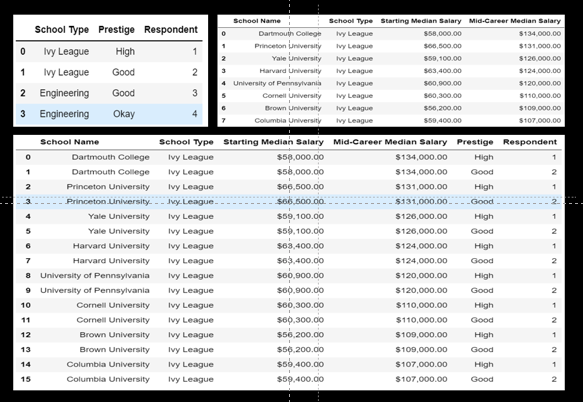

For every School we have two records , mapping the 'Prestige' column of 'survey' df

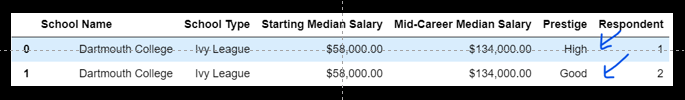

So in the 'ivy' data we have 8 schools , but afte merging with survey data , we end up with 16 schools.

```python
#Lets try to add another row to the survey data :
survey.append(pd.Series({'School Type' : 'Ivy League', 'Prestige' : 'Very High' , 'Respondent' : 5} , name = 4))
```

|  | School Type | Prestige | Respondent |
| --- | --- | --- | --- |
| 0 | Ivy League | High | 1 |
| 1 | Ivy League | Good | 2 |
| 2 | Engineering | Good | 3 |
| 3 | Engineering | Okay | 4 |
| 4 | Ivy League | Very High | 5 |

```python
#Lets assign this to survey
survey = survey.append(pd.Series({'School Type' : 'Ivy League', 'Prestige' : 'Very High' , 'Respondent' : 5} , name = 4))
```

```python
survey
```

|  | School Type | Prestige | Respondent |
| --- | --- | --- | --- |
| 0 | Ivy League | High | 1 |
| 1 | Ivy League | Good | 2 |
| 2 | Engineering | Good | 3 |
| 3 | Engineering | Okay | 4 |
| 4 | Ivy League | Very High | 5 |

- Now we have 3 duplicates for 'Ivy League'
- So, 3 (survey) X 8(Ivy) = should give us 24 records when merged

```python
pd.merge(survey , ivy)
```

|  | School Type | Prestige | Respondent | School Name | Starting Median Salary | Mid-Career Median Salary |
| --- | --- | --- | --- | --- | --- | --- |
| 0 | Ivy League | High | 1 | Dartmouth College | $58,000.00 | $134,000.00 |
| 1 | Ivy League | High | 1 | Princeton University | $66,500.00 | $131,000.00 |
| 2 | Ivy League | High | 1 | Yale University | $59,100.00 | $126,000.00 |
| 3 | Ivy League | High | 1 | Harvard University | $63,400.00 | $124,000.00 |
| 4 | Ivy League | High | 1 | University of Pennsylvania | $60,900.00 | $120,000.00 |
| 5 | Ivy League | High | 1 | Cornell University | $60,300.00 | $110,000.00 |
| 6 | Ivy League | High | 1 | Brown University | $56,200.00 | $109,000.00 |
| 7 | Ivy League | High | 1 | Columbia University | $59,400.00 | $107,000.00 |
| 8 | Ivy League | Good | 2 | Dartmouth College | $58,000.00 | $134,000.00 |
| 9 | Ivy League | Good | 2 | Princeton University | $66,500.00 | $131,000.00 |
| 10 | Ivy League | Good | 2 | Yale University | $59,100.00 | $126,000.00 |
| 11 | Ivy League | Good | 2 | Harvard University | $63,400.00 | $124,000.00 |
| 12 | Ivy League | Good | 2 | University of Pennsylvania | $60,900.00 | $120,000.00 |
| 13 | Ivy League | Good | 2 | Cornell University | $60,300.00 | $110,000.00 |
| 14 | Ivy League | Good | 2 | Brown University | $56,200.00 | $109,000.00 |
| 15 | Ivy League | Good | 2 | Columbia University | $59,400.00 | $107,000.00 |
| 16 | Ivy League | Very High | 5 | Dartmouth College | $58,000.00 | $134,000.00 |
| 17 | Ivy League | Very High | 5 | Princeton University | $66,500.00 | $131,000.00 |
| 18 | Ivy League | Very High | 5 | Yale University | $59,100.00 | $126,000.00 |
| 19 | Ivy League | Very High | 5 | Harvard University | $63,400.00 | $124,000.00 |
| 20 | Ivy League | Very High | 5 | University of Pennsylvania | $60,900.00 | $120,000.00 |
| 21 | Ivy League | Very High | 5 | Cornell University | $60,300.00 | $110,000.00 |
| 22 | Ivy League | Very High | 5 | Brown University | $56,200.00 | $109,000.00 |
| 23 | Ivy League | Very High | 5 | Columbia University | $59,400.00 | $107,000.00 |

This type of behaviour where it multiplies is called the Cartesian product

- This arises when there are duplicated values on the 'Key' columns for both objects being merged.

#### Summary:

Join Cardinalities:

To differentiate between One-To-One ; One-To-Many and Many-To-Many, we simply look for repeating values in the respective Key columns that the Key values that the two merged objects have in common.

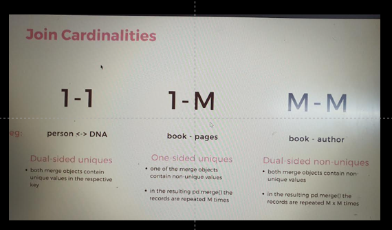

### Merging by Index

Above we saw , Pandas utilizes a common column as a Key column for the merge

- We also use the "on" parameter to explicitly specify the column
- We explored the "left-on" and "right-on" parameters to pass different "key" columns from the right and left objects
- In all these we performed join operations using plain dataframe columns
- Occassionally , we might be interested in joining by index instead
- Fortunately , the Pandas merge() method fully supports that

```python
#setting 'School Name' as index for ivy dataframe
ivy4 = ivy.set_index('School Name')
```

```python
ivy4
```

| School Name | School Type | Starting Median Salary | Mid-Career Median Salary |
| --- | --- | --- | --- |
| Dartmouth College | Ivy League | $58,000.00 | $134,000.00 |
| Princeton University | Ivy League | $66,500.00 | $131,000.00 |
| Yale University | Ivy League | $59,100.00 | $126,000.00 |
| Harvard University | Ivy League | $63,400.00 | $124,000.00 |
| University of Pennsylvania | Ivy League | $60,900.00 | $120,000.00 |
| Cornell University | Ivy League | $60,300.00 | $110,000.00 |
| Brown University | Ivy League | $56,200.00 | $109,000.00 |
| Columbia University | Ivy League | $59,400.00 | $107,000.00 |

```python
regions = pd.read_csv('regions.csv')
```

```python
regions2 = regions.set_index('School Name')
```

```python
regions2
```

| School Name | Region |
| --- | --- |
| Massachusetts Institute of Technology (MIT) | Northeastern |
| California Institute of Technology (CIT) | California |
| Harvey Mudd College | California |
| Polytechnic University of New York, Brooklyn | Northeastern |
| Cooper Union | Northeastern |
| ... | ... |
| Austin Peay State University | Southern |
| Pittsburg State University | Midwestern |
| Southern Utah University | Western |
| Montana State University - Billings | Western |
| Black Hills State University | Midwestern |

269 rows × 1 columns

```python
'''If we try to merge these two dataframes , pandas will rightly complain , that it has no common
column to perform the merge on.'''
```

```python
pd.merge(ivy4 , regions2)
```

[output not shown]

- We need a way to tell pandas to do the merge using the Index axis as the key column.
- To do that we use the Left index and Right index paramters to act as key columns for the join

```python
pd.merge(ivy4 , regions2 , left_index = True , right_index = True)
```

| School Name | School Type | Starting Median Salary | Mid-Career Median Salary | Region |
| --- | --- | --- | --- | --- |
| Brown University | Ivy League | $56,200.00 | $109,000.00 | Northeastern |
| Columbia University | Ivy League | $59,400.00 | $107,000.00 | Northeastern |
| Cornell University | Ivy League | $60,300.00 | $110,000.00 | Northeastern |
| Dartmouth College | Ivy League | $58,000.00 | $134,000.00 | Northeastern |
| Harvard University | Ivy League | $63,400.00 | $124,000.00 | Northeastern |
| Princeton University | Ivy League | $66,500.00 | $131,000.00 | Northeastern |
| University of Pennsylvania | Ivy League | $60,900.00 | $120,000.00 | Northeastern |
| Yale University | Ivy League | $59,100.00 | $126,000.00 | Northeastern |

```python
(pd.merge(ivy4 , regions2 , left_index = True , right_index = True)).shape
```

```
(8, 4)
```

[figure not shown]

If we want to merge using the Index on one dataframe and a column on the other.

- This could be done using right_index + right_on etc

```python
#Combination of index and column merge
```

- ivy4 has "School Name" as index
- regions has "School Name" as column

```python
ivy4
```

| School Name | School Type | Starting Median Salary | Mid-Career Median Salary |
| --- | --- | --- | --- |
| Dartmouth College | Ivy League | $58,000.00 | $134,000.00 |
| Princeton University | Ivy League | $66,500.00 | $131,000.00 |
| Yale University | Ivy League | $59,100.00 | $126,000.00 |
| Harvard University | Ivy League | $63,400.00 | $124,000.00 |
| University of Pennsylvania | Ivy League | $60,900.00 | $120,000.00 |
| Cornell University | Ivy League | $60,300.00 | $110,000.00 |
| Brown University | Ivy League | $56,200.00 | $109,000.00 |
| Columbia University | Ivy League | $59,400.00 | $107,000.00 |

```python
regions.head(4)
```

|  | School Name | Region |
| --- | --- | --- |
| 0 | Massachusetts Institute of Technology (MIT) | Northeastern |
| 1 | California Institute of Technology (CIT) | California |
| 2 | Harvey Mudd College | California |
| 3 | Polytechnic University of New York, Brooklyn | Northeastern |

```python
pd.merge(ivy4 , regions , left_index = True , right_on = 'School Name')
```

|  | School Type | Starting Median Salary | Mid-Career Median Salary | School Name | Region |
| --- | --- | --- | --- | --- | --- |
| 86 | Ivy League | $58,000.00 | $134,000.00 | Dartmouth College | Northeastern |
| 87 | Ivy League | $66,500.00 | $131,000.00 | Princeton University | Northeastern |
| 88 | Ivy League | $59,100.00 | $126,000.00 | Yale University | Northeastern |
| 89 | Ivy League | $63,400.00 | $124,000.00 | Harvard University | Northeastern |
| 90 | Ivy League | $60,900.00 | $120,000.00 | University of Pennsylvania | Northeastern |
| 91 | Ivy League | $60,300.00 | $110,000.00 | Cornell University | Northeastern |
| 92 | Ivy League | $56,200.00 | $109,000.00 | Brown University | Northeastern |
| 93 | Ivy League | $59,400.00 | $107,000.00 | Columbia University | Northeastern |

### The join() method

```python
#We can simply use join to join two dataframes
#ivy4 and regions2 : both have 'School Name' as index
```

```python
#join()
ivy4.join(regions2)
```

| School Name | School Type | Starting Median Salary | Mid-Career Median Salary | Region |
| --- | --- | --- | --- | --- |
| Brown University | Ivy League | $56,200.00 | $109,000.00 | Northeastern |
| Columbia University | Ivy League | $59,400.00 | $107,000.00 | Northeastern |
| Cornell University | Ivy League | $60,300.00 | $110,000.00 | Northeastern |
| Dartmouth College | Ivy League | $58,000.00 | $134,000.00 | Northeastern |
| Harvard University | Ivy League | $63,400.00 | $124,000.00 | Northeastern |
| Princeton University | Ivy League | $66,500.00 | $131,000.00 | Northeastern |
| University of Pennsylvania | Ivy League | $60,900.00 | $120,000.00 | Northeastern |
| Yale University | Ivy League | $59,100.00 | $126,000.00 | Northeastern |

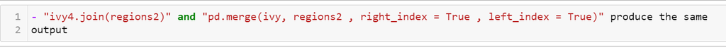

```python
#join() also supports : Index + column join
#ivy : "School Name" as column
#regions2 : "School Name" as index
```

```python
ivy.join(regions2 , on = 'School Name')
```

|  | School Name | School Type | Starting Median Salary | Mid-Career Median Salary | Region |
| --- | --- | --- | --- | --- | --- |
| 0 | Dartmouth College | Ivy League | $58,000.00 | $134,000.00 | Northeastern |
| 1 | Princeton University | Ivy League | $66,500.00 | $131,000.00 | Northeastern |
| 2 | Yale University | Ivy League | $59,100.00 | $126,000.00 | Northeastern |
| 3 | Harvard University | Ivy League | $63,400.00 | $124,000.00 | Northeastern |
| 4 | University of Pennsylvania | Ivy League | $60,900.00 | $120,000.00 | Northeastern |
| 5 | Cornell University | Ivy League | $60,300.00 | $110,000.00 | Northeastern |
| 6 | Brown University | Ivy League | $56,200.00 | $109,000.00 | Northeastern |
| 7 | Columbia University | Ivy League | $59,400.00 | $107,000.00 | Northeastern |

Think of join() as a convenience method to write shorter code

- under the hood join() calls the pandas merge() method

### Skill Challenge

#### Merge liberal arts schools with regions and assign the resulting dataframe to dfm. What region has the highest number of liberal arts schools.

```python
liberal.head(2)
```

|  | School Name | School Type | Starting Median Salary | Mid-Career Median Salary |
| --- | --- | --- | --- | --- |
| 0 | Bucknell University | Liberal Arts | $54,100.00 | $110,000.00 |
| 1 | Colgate University | Liberal Arts | $52,800.00 | $108,000.00 |

```python
regions.head(2)
```

|  | School Name | Region |
| --- | --- | --- |
| 0 | Massachusetts Institute of Technology (MIT) | Northeastern |
| 1 | California Institute of Technology (CIT) | California |

```python
liberal.shape
```

```
(47, 4)
```

```python
regions.shape
```

```
(269, 2)
```

```python
liberal['School Name'].is_unique
```

```
True
```

```python
regions['School Name'].is_unique
```

```
False
```

```python
pd.merge(liberal , regions)
```

|  | School Name | School Type | Starting Median Salary | Mid-Career Median Salary | Region |
| --- | --- | --- | --- | --- | --- |
| 0 | Bucknell University | Liberal Arts | $54,100.00 | $110,000.00 | Northeastern |
| 1 | Colgate University | Liberal Arts | $52,800.00 | $108,000.00 | Northeastern |
| 2 | Amherst College | Liberal Arts | $54,500.00 | $107,000.00 | Northeastern |
| 3 | Lafayette College | Liberal Arts | $53,900.00 | $107,000.00 | Northeastern |
| 4 | Bowdoin College | Liberal Arts | $48,100.00 | $107,000.00 | Northeastern |
| 5 | College of the Holy Cross | Liberal Arts | $50,200.00 | $106,000.00 | Northeastern |
| 6 | Occidental College | Liberal Arts | $51,900.00 | $105,000.00 | California |
| 7 | Washington and Lee University | Liberal Arts | $53,600.00 | $104,000.00 | Southern |
| 8 | Swarthmore College | Liberal Arts | $49,700.00 | $104,000.00 | Northeastern |
| 9 | Davidson College | Liberal Arts | $46,100.00 | $104,000.00 | Southern |
| 10 | Carleton College | Liberal Arts | $47,500.00 | $103,000.00 | Midwestern |
| 11 | Williams College | Liberal Arts | $51,700.00 | $102,000.00 | Northeastern |
| 12 | Pomona College | Liberal Arts | $48,600.00 | $101,000.00 | California |
| 13 | Wesleyan University (Middletown, Connecticut) | Liberal Arts | $46,500.00 | $97,900.00 | Northeastern |
| 14 | Bates College | Liberal Arts | $47,300.00 | $96,500.00 | Northeastern |
| 15 | Union College | Liberal Arts | $47,200.00 | $95,800.00 | Northeastern |
| 16 | University of Richmond | Liberal Arts | $48,600.00 | $94,600.00 | Southern |
| 17 | Vassar College | Liberal Arts | $46,000.00 | $94,600.00 | Northeastern |
| 18 | Middlebury College | Liberal Arts | $47,700.00 | $94,200.00 | Northeastern |
| 19 | Mount Holyoke College | Liberal Arts | $42,400.00 | $94,100.00 | Northeastern |
| 20 | Franklin and Marshall College | Liberal Arts | $49,100.00 | $92,800.00 | Northeastern |
| 21 | DePauw University | Liberal Arts | $41,400.00 | $88,300.00 | Midwestern |
| 22 | St. Olaf College | Liberal Arts | $45,300.00 | $86,200.00 | Midwestern |
| 23 | Colby College | Liberal Arts | $46,400.00 | $85,800.00 | Northeastern |
| 24 | Gettysburg College | Liberal Arts | $44,700.00 | $85,800.00 | Northeastern |
| 25 | Siena College | Liberal Arts | $45,500.00 | $85,200.00 | Northeastern |
| 26 | Smith College | Liberal Arts | $44,000.00 | $83,900.00 | Northeastern |
| 27 | Hamilton College | Liberal Arts | $49,200.00 | $83,700.00 | Northeastern |
| 28 | Randolph-Macon College | Liberal Arts | $42,600.00 | $83,600.00 | Southern |
| 29 | Randolph-Macon College | Liberal Arts | $42,600.00 | $83,600.00 | Southern |
| 30 | Wellesley College | Liberal Arts | $42,800.00 | $83,500.00 | Northeastern |
| 31 | Denison University | Liberal Arts | $42,000.00 | $83,500.00 | Midwestern |
| 32 | Oberlin College | Liberal Arts | $43,400.00 | $81,600.00 | Midwestern |
| 33 | University of Puget Sound | Liberal Arts | $46,600.00 | $81,500.00 | Western |
| 34 | Colorado College (CC) | Liberal Arts | $38,500.00 | $81,400.00 | Western |
| 35 | Reed College | Liberal Arts | $40,500.00 | $81,100.00 | Western |
| 36 | Gustavus Adolphus College | Liberal Arts | $44,500.00 | $80,600.00 | Midwestern |
| 37 | Whitman College | Liberal Arts | $43,500.00 | $80,100.00 | Western |
| 38 | Ursinus College | Liberal Arts | $42,100.00 | $80,000.00 | Northeastern |
| 39 | Juniata College | Liberal Arts | $41,800.00 | $78,900.00 | Northeastern |
| 40 | Wittenberg University | Liberal Arts | $39,200.00 | $78,200.00 | Midwestern |
| 41 | Grinnell College | Liberal Arts | $42,600.00 | $76,600.00 | Midwestern |
| 42 | Skidmore College | Liberal Arts | $41,600.00 | $74,600.00 | Northeastern |
| 43 | Moravian College | Liberal Arts | $42,500.00 | $74,400.00 | Northeastern |
| 44 | Lewis & Clark College | Liberal Arts | $38,900.00 | $72,600.00 | Western |
| 45 | Fort Lewis College | Liberal Arts | $42,000.00 | $69,800.00 | Western |
| 46 | Thomas Aquinas College | Liberal Arts | $41,500.00 | $67,500.00 | California |
| 47 | Evergreen State College | Liberal Arts | $39,500.00 | $63,900.00 | Western |

```python
dfm = pd.merge(liberal , regions)
```

```python
#Region with highest number of liberal arts schools
```

```python
dfm.columns
```

```
Index(['School Name', 'School Type', 'Starting Median Salary',
       'Mid-Career Median Salary', 'Region'],
      dtype='object')
```

```python
dfm['Region'].value_counts()
```

```
Northeastern    25
Midwestern       8
Western          7
Southern         5
California       3
Name: Region, dtype: int64
```

- Northeastern region has the highest number of liberal arts schools